# Anthony Mahshigian

Introduction: I am going to give a tutorial about analyzing COVID-19 data exclusively in the United States. When trying to pick a topic that has relevance, and I'm personally motivated to analyze, nothing is more prevalant than COVID-19 right now, as I am studying the topic of data science online, due to COVID-19. There is plenty of data to examine, and it is so widely availible. It is also easy to verify data sources are accurate since there are so many out there that incorrect data would look suprising. There are many questions surrounding COVID-19. How deadly is it? Is it getting worse? Are we treating it better? When will it be over? If anyone had the answers to these questions, they would be very famous by now. We can, however, gain plenty of insight through data science and make some great analysis related to these questions. I wish to the answer the main question of if it's getting worse. Specifically, I'm going to compare different metrics like case numbers and death numbers, among other things.The Source: The source I'm going to use for this data is the COVID Tracking Project. This database was shown to me by following Nate Silver from 538 and his data analysis. This tag can be found on their website: https://fivethirtyeight.com/tag/covid-19/ where there are plenty of data-driven articles analyzing just about everything related to COVID-19. Following this news organization is a great way to get a data science perspective on what's going on in the world around us. The database I'm using is the COVID Tracking Project: https://covidtracking.com This is a compilation of data from state government authorities that has a track record during the pandemic of providing generally accurate data. There seems to be no source of bias and bias is an easy thing to spot for a topic with so much national attention. You can compare datasets with each other to verify consistency. With something so publicly availible across multiple sources, it would be easy to spot discrepencies. The COVID Tracking Project seems to be consistent across other sources. This website is a great place to explore the data. They have a CSV of all current data, an interative API, and a web-friendly way to view the data at a high level. For this tutorial, I have decided to navigate to the total data for the US and download the CSV. By downloading the CSV, I have a local copy of the data that can be viewed without an internet connection, making this the choice for gathering my data. There is also a FAQ about this specific dataset, and any potential concerns or questions are very well addressed https://covidtracking.com/about-data/faq

```python
# import all the packages we need
# pandas will give us a good way to read/analyze the CSV. Matplotlib to visualize the datam, numpy for math/ranges, datetime/timedelta for dates, smf for linear regression
import pandas as pd
import matplotlib.pyplot as plt
import numpy as np
from datetime import datetime
from datetime import timedelta
import statsmodels.formula.api as smf
```

# Gathering The Data

```python
# I have downloaded a local copy of the file. This lets me view the data without an internet connection. I read it with pandas
filename = "covid.csv"
df = pd.read_csv(filename)
```

```python
# here's an example of how the dataframe looks once read
df
# empty values default to NaN
```

|  | date | states | positive | negative | pending | hospitalizedCurrently | hospitalizedCumulative | inIcuCurrently | inIcuCumulative | onVentilatorCurrently | ... | lastModified | total | totalTestResults | posNeg | deathIncrease | hospitalizedIncrease | negativeIncrease | positiveIncrease | totalTestResultsIncrease | hash |
| --- | --- | --- | --- | --- | --- | --- | --- | --- | --- | --- | --- | --- | --- | --- | --- | --- | --- | --- | --- | --- | --- |
| 0 | 20200718 | 56 | 3692061 | 41273443 | 3032.0 | 57562.0 | 276439.0 | 6396.0 | 12342.0 | 2343.0 | ... | 2020-07-18T00:00:00Z | 44968536 | 44965504 | 44965504 | 872 | 2003 | 696591 | 65180 | 761771 | a6838d287f4a1270b49fde1e76e01bab4e2d7b2e |
| 1 | 20200717 | 56 | 3626881 | 40576852 | 3002.0 | 57705.0 | 274436.0 | 6453.0 | 12243.0 | 2353.0 | ... | 2020-07-17T00:00:00Z | 44206735 | 44203733 | 44203733 | 951 | 2678 | 774555 | 77233 | 851788 | 2fd5fa9462df840f6808d6757e4d13f702be8fdb |
| 2 | 20200716 | 56 | 3549648 | 39802297 | 2929.0 | 57369.0 | 271758.0 | 6359.0 | 12091.0 | 2317.0 | ... | 2020-07-16T00:00:00Z | 43354874 | 43351945 | 43351945 | 977 | 2251 | 759689 | 71229 | 830918 | 8644aacf2b4997ff08daf87ae088c7f6a44cb367 |
| 3 | 20200715 | 56 | 3478419 | 39042608 | 2947.0 | 56171.0 | 269507.0 | 6328.0 | 12002.0 | 2322.0 | ... | 2020-07-15T00:00:00Z | 42523974 | 42521027 | 42521027 | 855 | 2380 | 691364 | 65106 | 756470 | 6134b719e380f36d562a13ce421afcda53efdc26 |
| 4 | 20200714 | 56 | 3413313 | 38351244 | 960.0 | 55533.0 | 267127.0 | 6235.0 | 11857.0 | 2263.0 | ... | 2020-07-14T00:00:00Z | 41765517 | 41764557 | 41764557 | 736 | 2262 | 697403 | 62879 | 760282 | 9fff665c0a4f59af0ca8746fa5d90e91b35c0967 |
| ... | ... | ... | ... | ... | ... | ... | ... | ... | ... | ... | ... | ... | ... | ... | ... | ... | ... | ... | ... | ... | ... |
| 174 | 20200126 | 1 | 2 | 0 | NaN | NaN | NaN | NaN | NaN | NaN | ... | 2020-01-26T00:00:00Z | 2 | 2 | 2 | 0 | 0 | 0 | 0 | 0 | e1cf59ab48e1cf367c4a6798a508a23d9d36bd18 |
| 175 | 20200125 | 1 | 2 | 0 | NaN | NaN | NaN | NaN | NaN | NaN | ... | 2020-01-25T00:00:00Z | 2 | 2 | 2 | 0 | 0 | 0 | 0 | 0 | bef2a1d5f2a13491e0e0369bbd46c10cdd12973b |
| 176 | 20200124 | 1 | 2 | 0 | NaN | NaN | NaN | NaN | NaN | NaN | ... | 2020-01-24T00:00:00Z | 2 | 2 | 2 | 0 | 0 | 0 | 0 | 0 | bfffe76fc0b7cf11efe8aecd3cc7b22598d77d61 |
| 177 | 20200123 | 1 | 2 | 0 | NaN | NaN | NaN | NaN | NaN | NaN | ... | 2020-01-23T00:00:00Z | 2 | 2 | 2 | 0 | 0 | 0 | 0 | 0 | cee36ebf3174bf1df0daa36e1e8088a157406fad |
| 178 | 20200122 | 1 | 2 | 0 | NaN | NaN | NaN | NaN | NaN | NaN | ... | 2020-01-22T00:00:00Z | 2 | 2 | 2 | 0 | 0 | 0 | 0 | 0 | d538c99729d1fee626212d1878a100c1e1204a5f |

179 rows × 25 columns

Let's look at what data we have. The columns are: - date - states - positive - negative - pending - hospitalizedCurrently - hospitalizedCumulative - inIcuCurrently - inIcuCumulative - onVentilatorCurrently - onVentilatorCumulative - recovered - dateChecked - death - hospitalized - lastModified - total - totalTestResults - posNeg - deathIncrease - hospitalizedIncrease - negativeIncrease - positiveIncrease - totalTestResultsIncrease - hash This right here is a lot to unpack. We have data about hospital usage, cases/percentages of tests, deaths, and more. We can use this to gain a lot of insight into the data. Let's start by getting a sense of how the trends look in the United States.

# Are Cases Rising?

First, I am going to look at case numbers for the nation. This will tell us how many people are testing positive. But there has been a lot of speculation that many who had COVID were never tested. A good way to get a better sense of this is to look at the % that test positive using positive and negative test numbers

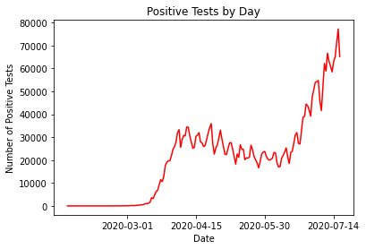

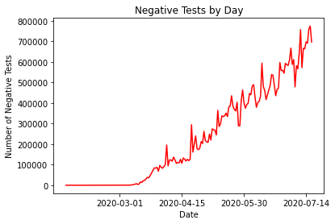

```python
# New Cases By Day
date = []
newcases = []
for row in df.iterrows():
    date.append(datetime(int(str(row[1]['date'])[:4]), int(str(row[1]['date'])[4:6]), int(str(row[1]['date'])[6:8])))
    newcases.append(row[1]['positiveIncrease'])
plt.plot(date, newcases, 'r-')
plt.title("Positive Tests by Day")
plt.xlabel("Date")
plt.ylabel("Number of Positive Tests")
plt.xticks(np.arange(datetime(2020, 3, 1), datetime(2020, 7, 18), timedelta(days=45)))
plt.show()
# We can see that the number has definetly risen

# New negative tests by day
date = []
newneg = []
for row in df.iterrows():
    date.append(datetime(int(str(row[1]['date'])[:4]), int(str(row[1]['date'])[4:6]), int(str(row[1]['date'])[6:8])))
    newneg.append(row[1]['negativeIncrease'])
plt.plot(date, newneg, 'r-')
plt.title("Negative Tests by Day")
plt.xlabel("Date")
plt.ylabel("Number of Negative Tests")
plt.xticks(np.arange(datetime(2020, 3, 1), datetime(2020, 7, 18), timedelta(days=45)))
plt.show()
# This shows us that the negative tests per day has also risen.
```

Without looking at the negative tests rising, it looks like positive cases are explicitly rising, and we don't consider the effects due to limited testing. As testing increases, we can see an increase in negative tests. Just by looking at negative tests, we'd think the number of positives is decreasing. Both are rising. By intuituon and seeing that negative is rising at a generally linear rate, and positive is exponential shows us that we could be in trouble. Let's look at two things, first a linear regression of the two to point out how the rates are different

```python
# Linear Regression
model = smf.ols(formula='positiveIncrease ~ date', data=df).fit()
model2 = smf.ols(formula='negativeIncrease ~ date', data=df).fit()
display(model.summary())
display(model.params)
display(model2.summary())
display(model2.params)
```

OLS Regression Results

| Dep. Variable: | positiveIncrease | R-squared: | 0.726 |
| --- | --- | --- | --- |
| Model: | OLS | Adj. R-squared: | 0.725 |
| Method: | Least Squares | F-statistic: | 469.7 |
| Date: | Sun, 19 Jul 2020 | Prob (F-statistic): | 1.11e-51 |
| Time: | 23:55:47 | Log-Likelihood: | -1894.5 |
| No. Observations: | 179 | AIC: | 3793. |
| Df Residuals: | 177 | BIC: | 3799. |
| Df Model: | 1 |  |  |
| Covariance Type: | nonrobust |  |  |

|  | coef | std err | t | P>\|t\| | [0.025 | 0.975] |
| --- | --- | --- | --- | --- | --- | --- |
| Intercept | -1.819e+09 | 8.39e+07 | -21.671 | 0.000 | -1.98e+09 | -1.65e+09 |
| date | 90.0380 | 4.155 | 21.671 | 0.000 | 81.839 | 98.237 |

| Omnibus: | 2.934 | Durbin-Watson: | 0.108 |
| --- | --- | --- | --- |
| Prob(Omnibus): | 0.231 | Jarque-Bera (JB): | 2.970 |
| Skew: | 0.282 | Prob(JB): | 0.227 |
| Kurtosis: | 2.716 | Cond. No. | 2.36e+12 |

Warnings:  
[1] Standard Errors assume that the covariance matrix of the errors is correctly specified.  
[2] The condition number is large, 2.36e+12. This might indicate that there are  
strong multicollinearity or other numerical problems.

```
Intercept   -1.818785e+09
date         9.003799e+01
dtype: float64
```

OLS Regression Results

| Dep. Variable: | negativeIncrease | R-squared: | 0.894 |
| --- | --- | --- | --- |
| Model: | OLS | Adj. R-squared: | 0.894 |
| Method: | Least Squares | F-statistic: | 1495. |
| Date: | Sun, 19 Jul 2020 | Prob (F-statistic): | 3.07e-88 |
| Time: | 23:55:47 | Log-Likelihood: | -2260.9 |
| No. Observations: | 179 | AIC: | 4526. |
| Df Residuals: | 177 | BIC: | 4532. |
| Df Model: | 1 |  |  |
| Covariance Type: | nonrobust |  |  |

|  | coef | std err | t | P>\|t\| | [0.025 | 0.975] |
| --- | --- | --- | --- | --- | --- | --- |
| Intercept | -2.513e+10 | 6.5e+08 | -38.667 | 0.000 | -2.64e+10 | -2.38e+10 |
| date | 1243.9934 | 32.172 | 38.667 | 0.000 | 1180.504 | 1307.483 |

| Omnibus: | 10.778 | Durbin-Watson: | 0.395 |
| --- | --- | --- | --- |
| Prob(Omnibus): | 0.005 | Jarque-Bera (JB): | 9.376 |
| Skew: | 0.482 | Prob(JB): | 0.00921 |
| Kurtosis: | 2.426 | Cond. No. | 2.36e+12 |

Warnings:  
[1] Standard Errors assume that the covariance matrix of the errors is correctly specified.  
[2] The condition number is large, 2.36e+12. This might indicate that there are  
strong multicollinearity or other numerical problems.

```
Intercept   -2.512897e+10
date         1.243993e+03
dtype: float64
```

From the linear regression, we see that the number of negative tests is rising at a rate 10+ times more than the positive numbers, but there is a reason for this. The number of positive tests was much higher than negatives to start. So a linear regression is very difficult to apply to this data. It's good for something linear like the negative count, but it is having a difficulty capturing the recent trend of the spike. I'm going to make a new calculation. The % of positives per day. This should give us a view of the cases in the context of the total number of tests being conducted. Let's see if this gives more of an accurate view.

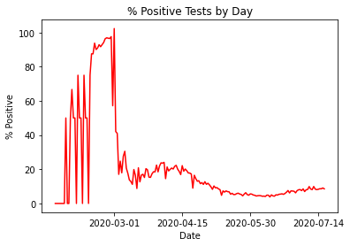

```python
# % positive tests by day
date = []
percent = []
for row in df.iterrows():
    date.append(datetime(int(str(row[1]['date'])[:4]), int(str(row[1]['date'])[4:6]), int(str(row[1]['date'])[6:8])))
    percent.append(100 * row[1]['positiveIncrease'] / (1 + row[1]['positiveIncrease'] + row[1]['negativeIncrease']))
    # to avoid division by zero, add 1 to denomenator
plt.plot(date, percent, 'r-')
plt.title("% Positive Tests by Day")
plt.xlabel("Date")
plt.ylabel("% Positive")
plt.xticks(np.arange(datetime(2020, 3, 1), datetime(2020, 7, 18), timedelta(days=45)))
plt.show()
```

The percent positive test data makes it look like it has gotten tremendously better. The first month or so, cases and especially tests were very limited. Tests were exclusivly given to people highly suspected of having the disease, which is why we see such high rates of positive tests. Let's exclude the first month or so to see better into the trends with more tests availible. Espcecially so the recent trend isn't seen as insignificant, since it looks very small compared to the early percentages.

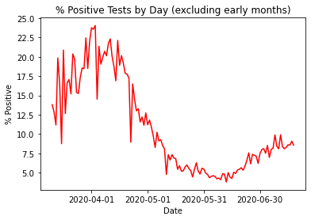

```python
# % positive tests by day 2.0
date2 = []
percent2 = []
for row in df.iterrows():
    if (int(row[0]) < 130):   #number obtained experimentally
        date2.append(datetime(int(str(row[1]['date'])[:4]), int(str(row[1]['date'])[4:6]), int(str(row[1]['date'])[6:8])))
        percent2.append(100 * row[1]['positiveIncrease'] / (1 + row[1]['positiveIncrease'] + row[1]['negativeIncrease']))
        # to avoid division by zero, add 1 to denomenator
plt.plot(date2, percent2, 'r-')
plt.title("% Positive Tests by Day (excluding early months)")
plt.xlabel("Date")
plt.ylabel("% Positive")
plt.xticks(np.arange(datetime(2020, 4, 1), datetime(2020, 7, 18), timedelta(days=30)))
plt.show()
```

# Further Analysis into Hospitalizations

Let's take our analysis to the next level. Let's look at the hospitalizations due to COVID and compare them to case numbers. Hopefully, this will be a better way to view the virus becuase of the issues with cases, due to limited testing. I have a hypothesis that a lower percentage of cases are being hospitalized. The motivation for this hypothesis is that more cases (and less severe cases) are being caught with an increase in testing, as well as possible better at home treatments, or the hospitals being able to discharge quicker with better treatments. To examine all of this, first let's look at the number of hospitalizations, number in ICU, and number on ventaliators

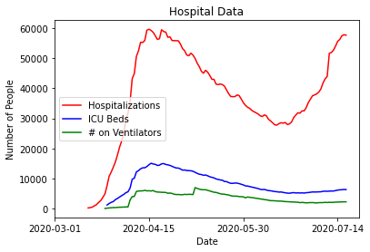

```python
date = []
hospital = []
ICU = []
vent = []
for row in df.iterrows():
    date.append(datetime(int(str(row[1]['date'])[:4]), int(str(row[1]['date'])[4:6]), int(str(row[1]['date'])[6:8])))
    hospital.append(row[1]['hospitalizedCurrently'])
    ICU.append(row[1]['inIcuCurrently'])
    vent.append(row[1]['onVentilatorCurrently'])
plt.plot(date, hospital, 'r-', date, ICU, 'b-', date, vent, 'g-')
plt.title("Hospital Data")
plt.legend(['Hospitalizations', 'ICU Beds', '# on Ventilators'])
plt.xlabel("Date")
plt.ylabel("Number of People")
plt.xticks(np.arange(datetime(2020, 3, 1), datetime(2020, 7, 18), timedelta(days=45)))
plt.show()
```

We can see similar trends here. I would use a linear regression to see the trends, but as we have seen for positive cases, it has a major pitfall. It is not good at sensing the second spike we are currently seeing. There are ways around this, like beginning to apply at the dip, but instead I am going to standardize the numbers with respect to their means so we can compare how the numbers look with resepct to each other.

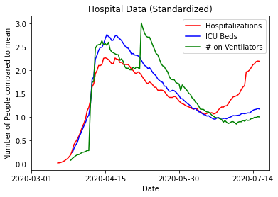

```python
num = 0
sumH = 0
sumICU = 0
sumVent = 0
for row in df.iterrows():
    num = num + 1
    if (row[1]['hospitalizedCurrently'] > 0):
        sumH = sumH + (row[1]['hospitalizedCurrently'])
    if (row[1]['inIcuCurrently'] > 0):
        sumICU = sumICU + (row[1]['inIcuCurrently'])
    if (row[1]['onVentilatorCurrently'] > 0):
        sumVent = sumVent + (row[1]['onVentilatorCurrently'])
meanH = sumH / num
meanICU = sumICU / num
meanVent = sumVent / num
date2 = []
hospital2 = []
ICU2 = []
vent2 = []
for row in df.iterrows():
    date2.append(datetime(int(str(row[1]['date'])[:4]), int(str(row[1]['date'])[4:6]), int(str(row[1]['date'])[6:8])))
    hospital2.append(row[1]['hospitalizedCurrently'] / meanH)
    ICU2.append(row[1]['inIcuCurrently'] / meanICU)
    vent2.append(row[1]['onVentilatorCurrently'] / meanVent)
plt.plot(date2, hospital2, 'r-', date2, ICU2, 'b-', date2, vent2, 'g-')
plt.title("Hospital Data (Standardized)")
plt.legend(['Hospitalizations', 'ICU Beds', '# on Ventilators'])
plt.xlabel("Date")
plt.ylabel("Number of People compared to mean")
plt.xticks(np.arange(datetime(2020, 3, 1), datetime(2020, 7, 18), timedelta(days=45)))
plt.show()
```

This is good news for anyone concerned about the severity of COVID. It looks like while there has been a recent rise of hospitalizations, a lower proportion of them are resulting in ICU beds or ventilators. This partially confirms the hpyothesis that the treatments are getting better. Another possible reason for this is that a younger share of the population is getting COVID. Since there has been so much public awareness, the population likely to be able to stay home are older, more at risk people, while the youth make up a good share of essential workers or people likely to venture out to grocery stores and other public activities. So it is likely that either treatments are getting better, a younger share of the population is becoming diagnosed, or some combination of the two. To confirm all of this, let's compare hospitalizations to number of cases and % of cases

[figure not shown]

```python
num = 0
sumCases = 0
sumH = 0
sumPercent = 0
for row in df.iterrows():
    num = num + 1
    if (row[1]['positiveIncrease'] > 0):
        sumCases = sumCases + (row[1]['positiveIncrease'])
    if (row[1]['hospitalizedCurrently'] > 0):
        sumH = sumH + (row[1]['hospitalizedCurrently'])
    sumPercent = sumPercent + (row[1]['positiveIncrease'] / (1 + row[1]['positiveIncrease'] + row[1]['negativeIncrease']))
meanCases = sumCases / num
meanH = sumH / num
meanPercent = sumPercent / num
date = []
cases = []
hospital = []
percent = []
for row in df.iterrows():
    date.append(datetime(int(str(row[1]['date'])[:4]), int(str(row[1]['date'])[4:6]), int(str(row[1]['date'])[6:8])))
    cases.append(row[1]['positiveIncrease'] / meanCases)
    hospital.append(row[1]['hospitalizedCurrently'] / meanH)
    percent.append((row[1]['positiveIncrease'] / (1 + row[1]['positiveIncrease'] + row[1]['negativeIncrease'])) / meanPercent)
plt.plot(date, cases, 'r-', date, hospital, 'b-', date, percent, 'g-')
plt.title("Cases/Hospitalizations Standardized")
plt.xlabel("Date")
plt.ylabel("Number compared to mean")
plt.legend(['Cases', 'Hospitalizations', '% Positive'])
plt.xticks(np.arange(datetime(2020, 3, 1), datetime(2020, 7, 18), timedelta(days=45)))
plt.show()
```

From this graph above, we can gain further insight. While the number of cases has risen a lot recently, the % has only slightly risen. This means the number of cases increasing is partially due to more tests. The hospitalizaions are increasing though, and at a higher trend than the % positive. This could mean that a larger share of people are getting hospitalized. Since we have conflicting data, there is another metric we can use to truly answer the question of if it's getting worse. To answer that, we'll look at the deaths per day.

# Using Deaths to Understand Severity

First, I am going to compare the number of deaths per day to the number of cases per day. The goal of this is to see if COVID is becoming more or less deadly. Ultimately, I would like to compare hospitalizations to deaths. I am going to standardize these numbers since they have differenc ranges

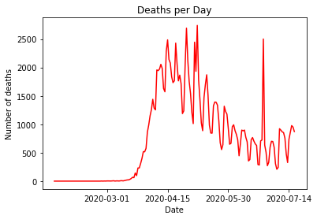

```python
date = []
deaths = []
for row in df.iterrows():
    date.append(datetime(int(str(row[1]['date'])[:4]), int(str(row[1]['date'])[4:6]), int(str(row[1]['date'])[6:8])))
    deaths.append(row[1]['deathIncrease'])
plt.plot(date, deaths, 'r-')
plt.title("Deaths per Day")
plt.xlabel("Date")
plt.ylabel("Number of deaths")
plt.xticks(np.arange(datetime(2020, 3, 1), datetime(2020, 7, 18), timedelta(days=45)))
plt.show()
# Deaths are slowly starting to increase again. The large spike is due to reclassifying old deaths
```

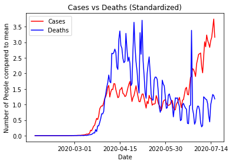

```python
num = 0
sumCases = 0
sumDeaths = 0
for row in df.iterrows():
    num = num + 1
    if (row[1]['positiveIncrease'] > 0):
        sumCases = sumCases + (row[1]['positiveIncrease'])
    if (row[1]['deathIncrease'] > 0):
        sumDeaths = sumDeaths + (row[1]['deathIncrease'])
meanCases = sumCases / num
meanDeaths = sumDeaths / num
date = []
cases = []
deaths = []
for row in df.iterrows():
    date.append(datetime(int(str(row[1]['date'])[:4]), int(str(row[1]['date'])[4:6]), int(str(row[1]['date'])[6:8])))
    cases.append(row[1]['positiveIncrease'] / meanCases)
    deaths.append(row[1]['deathIncrease'] / meanDeaths)
plt.plot(date, cases, 'r-', date, deaths, 'b-')
plt.title("Cases vs Deaths (Standardized)")
plt.legend(['Cases', 'Deaths'])
plt.xlabel("Date")
plt.ylabel("Number of People compared to mean")
plt.xticks(np.arange(datetime(2020, 3, 1), datetime(2020, 7, 18), timedelta(days=45)))
plt.show()
```

Recently, there has been a big increase in new cases, but deaths has not seen the same trend. This is a good thing! The deaths are increasing, indicating that there is still a spread, but less people are dying (much less). I am going to add in hospitalizations now

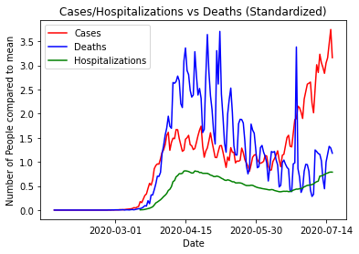

```python
num = 0
sumCases = 0
sumDeaths = 0
sumH
for row in df.iterrows():
    num = num + 1
    if (row[1]['positiveIncrease'] > 0):
        sumCases = sumCases + (row[1]['positiveIncrease'])
    if (row[1]['deathIncrease'] > 0):
        sumDeaths = sumDeaths + (row[1]['deathIncrease'])
    if (row[1]['hospitalizedCurrently'] > 0):
        sumH = sumH + (row[1]['hospitalizedCurrently'])
meanCases = sumCases / num
meanDeaths = sumDeaths / num
meanH = sumH / num
date = []
cases = []
deaths = []
hospital = []
for row in df.iterrows():
    date.append(datetime(int(str(row[1]['date'])[:4]), int(str(row[1]['date'])[4:6]), int(str(row[1]['date'])[6:8])))
    cases.append(row[1]['positiveIncrease'] / meanCases)
    deaths.append(row[1]['deathIncrease'] / meanDeaths)
    hospital.append(row[1]['hospitalizedCurrently'] / meanH)
plt.plot(date, cases, 'r-', date, deaths, 'b-', date, hospital, 'g-')
plt.title("Cases/Hospitalizations vs Deaths (Standardized)")
plt.legend(['Cases', 'Deaths', 'Hospitalizations'])
plt.xlabel("Date")
plt.ylabel("Number of People compared to mean")
plt.xticks(np.arange(datetime(2020, 3, 1), datetime(2020, 7, 18), timedelta(days=45)))
plt.show()
```

This confirms our hypothesis. Deaths have not increased as much as hospitalizations have. So a lower amount of people being hospitalized are dying. While we have seen a spread, it is less deadly. Let's review the recent trends - Number of cases are skyrocketing to all-time highs - Number of hospitalizations are returning to peak levels - Number of deaths are slightly rising, but nowhere near peak levels

# Conclusion and Further Reading